# 03 Data Analysis

Designed for Shantel

Harry Lu, dl947@cornell.edu

May/30/2022

HOME

# 1 Goal

- Learn the workflow of data analysis
  - EDA
  - Use built-in functions/customized algorithms to find the answer on a small scale dataset (statistical analysis or statistical modeling)
  - Scale the small analysis up to a large dataset
  - Automate/Semi-automate the work if needed
  - Present findings, generate reports, make recommendations to clients or stakeholders

# 2 Public Dataset

- How to find:
  - Google search “public dataset”
  - Data World
- Examples:
  - [Free Public Data Sets For Analysis | Tableau](https://www.tableau.com/learn/articles/free-public-data-sets)
  - [Find Open Datasets and Machine Learning Projects | Kaggle](https://www.kaggle.com/datasets)
  - https://data.world/health/asthma-ed-visit-rates-by-zip
  - More…

## 2.1 Iris

- Source: https://archive.ics.uci.edu/ml/datasets/Iris
- Download: https://archive.ics.uci.edu/ml/machine-learning-databases/iris/
  - `bezdekIris.data` or `iris.data`
  - `iris.names`

[figure not shown]

## 2.2 Wine

- Source: https://archive.ics.uci.edu/ml/datasets/Wine
- Download: https://archive.ics.uci.edu/ml/machine-learning-databases/wine/
  - `wine.data`
  - `wine.names`

## 2.3 Wine Quality

- Source: https://archive.ics.uci.edu/ml/datasets/Wine+Quality
- Download: https://archive.ics.uci.edu/ml/machine-learning-databases/wine-quality/
  - `winequality-red.csv`
  - `winequality-white.csv`
  - `winequality.names`

# 3 Exploratory Data Analysis (EDA)

1. Read dataset documentation, understand the background behind the data
2. Clean dataset
3. Summarize columns, understand the data

## 3.1 Example 1: Iris

### 3.1.1 Descriptions

- `../public_dataset/iris.names`

```r
file_1 = site_url %>%
  paste0("public_dataset/iris.names") %>%
  read_file()
```

```r
file_1 %>% cat()
```

```
1. Title: Iris Plants Database
    Updated Sept 21 by C.Blake - Added discrepency information

2. Sources:
     (a) Creator: R.A. Fisher
     (b) Donor: Michael Marshall (MARSHALL%PLU@io.arc.nasa.gov)
     (c) Date: July, 1988

3. Past Usage:
   - Publications: too many to mention!!!  Here are a few.
   1. Fisher,R.A. "The use of multiple measurements in taxonomic problems"
      Annual Eugenics, 7, Part II, 179-188 (1936); also in "Contributions
      to Mathematical Statistics" (John Wiley, NY, 1950).
   2. Duda,R.O., & Hart,P.E. (1973) Pattern Classification and Scene Analysis.
      (Q327.D83) John Wiley & Sons.  ISBN 0-471-22361-1.  See page 218.
   3. Dasarathy, B.V. (1980) "Nosing Around the Neighborhood: A New System
      Structure and Classification Rule for Recognition in Partially Exposed
      Environments".  IEEE Transactions on Pattern Analysis and Machine
      Intelligence, Vol. PAMI-2, No. 1, 67-71.
      -- Results:
         -- very low misclassification rates (0% for the setosa class)
   4. Gates, G.W. (1972) "The Reduced Nearest Neighbor Rule".  IEEE
      Transactions on Information Theory, May 1972, 431-433.
      -- Results:
         -- very low misclassification rates again
   5. See also: 1988 MLC Proceedings, 54-64.  Cheeseman et al's AUTOCLASS II
      conceptual clustering system finds 3 classes in the data.

4. Relevant Information:
   --- This is perhaps the best known database to be found in the pattern
       recognition literature.  Fisher's paper is a classic in the field
       and is referenced frequently to this day.  (See Duda & Hart, for
       example.)  The data set contains 3 classes of 50 instances each,
       where each class refers to a type of iris plant.  One class is
       linearly separable from the other 2; the latter are NOT linearly
       separable from each other.
   --- Predicted attribute: class of iris plant.
   --- This is an exceedingly simple domain.
   --- This data differs from the data presented in Fishers article
    (identified by Steve Chadwick,  spchadwick@espeedaz.net )
```

[output cut: 14 more lines]

```
   5. class:
      -- Iris Setosa
      -- Iris Versicolour
      -- Iris Virginica

8. Missing Attribute Values: None

Summary Statistics:
             Min  Max   Mean    SD   Class Correlation
   sepal length: 4.3  7.9   5.84  0.83    0.7826
    sepal width: 2.0  4.4   3.05  0.43   -0.4194
   petal length: 1.0  6.9   3.76  1.76    0.9490  (high!)
    petal width: 0.1  2.5   1.20  0.76    0.9565  (high!)

9. Class Distribution: 33.3% for each of 3 classes.
```

### 3.1.2 Raw dataset

- `../public_dataset/iris.data`

```r
df_1 = site_url %>%
  paste0("public_dataset/iris.data") %>%
  read_csv(col_names = FALSE)

colnames(df_1) = c("sepal_length", "sepal_width", "petal_length", "petal_width", "class")
```

```r
df_1
```

| sepal_length | sepal_width | petal_length | petal_width | class |
| --- | --- | --- | --- | --- |
| 5.1 | 3.5 | 1.4 | 0.2 | Iris-setosa |
| 4.9 | 3.0 | 1.4 | 0.2 | Iris-setosa |
| 4.7 | 3.2 | 1.3 | 0.2 | Iris-setosa |
| 4.6 | 3.1 | 1.5 | 0.2 | Iris-setosa |
| 5.0 | 3.6 | 1.4 | 0.2 | Iris-setosa |
| 5.4 | 3.9 | 1.7 | 0.4 | Iris-setosa |
| 4.6 | 3.4 | 1.4 | 0.3 | Iris-setosa |
| 5.0 | 3.4 | 1.5 | 0.2 | Iris-setosa |
| 4.4 | 2.9 | 1.4 | 0.2 | Iris-setosa |
| 4.9 | 3.1 | 1.5 | 0.1 | Iris-setosa |

[output cut: 140 more lines]

### 3.1.3 Clean dataset

- No need for cleaning

### 3.1.4 Inspect dataset

```r
df_1 %>% summary()
```

```
  sepal_length    sepal_width     petal_length    petal_width
 Min.   :4.300   Min.   :2.000   Min.   :1.000   Min.   :0.100
 1st Qu.:5.100   1st Qu.:2.800   1st Qu.:1.600   1st Qu.:0.300
 Median :5.800   Median :3.000   Median :4.350   Median :1.300
 Mean   :5.843   Mean   :3.054   Mean   :3.759   Mean   :1.199
 3rd Qu.:6.400   3rd Qu.:3.300   3rd Qu.:5.100   3rd Qu.:1.800
 Max.   :7.900   Max.   :4.400   Max.   :6.900   Max.   :2.500
    class
 Length:150
 Class :character
 Mode  :character
```

### 3.1.5 Visualize dataset

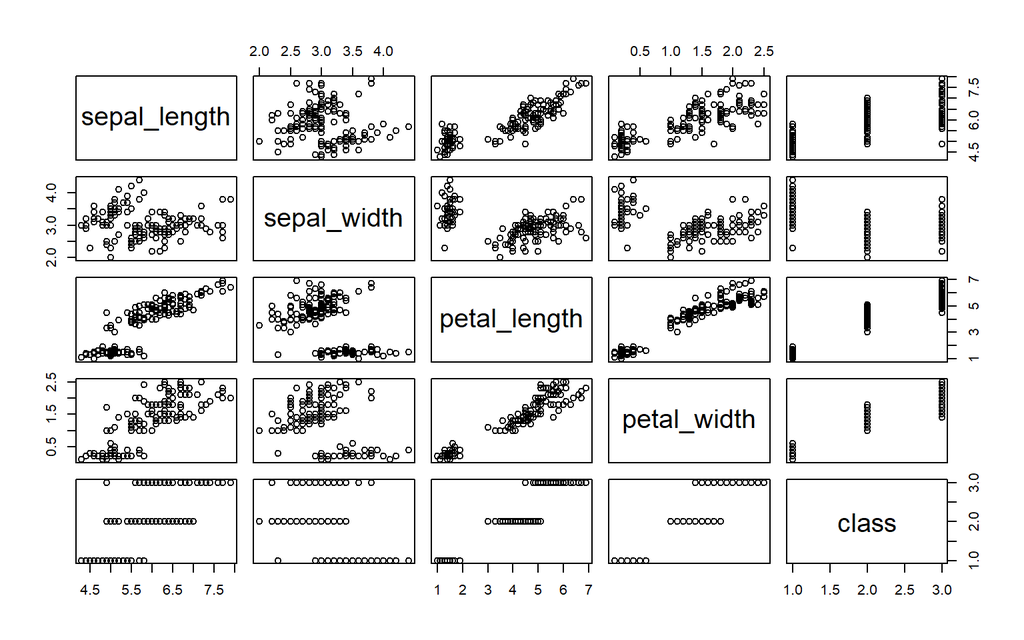

```r
plot(df_1)
```

1. Sepal length v.s. sepal width

```r
df_1_p_1 = ggplot(data = df_1,
                  mapping = aes(x = sepal_length,
                                y = sepal_width,
                                color = class)) +
  geom_point() +
  ggtitle("Sepal length v.s. Sepal width") +
  xlab("Sepal length") +
  ylab("Sepal width") +
  theme(plot.title = element_text(size = 15, hjust = 0.5))
```

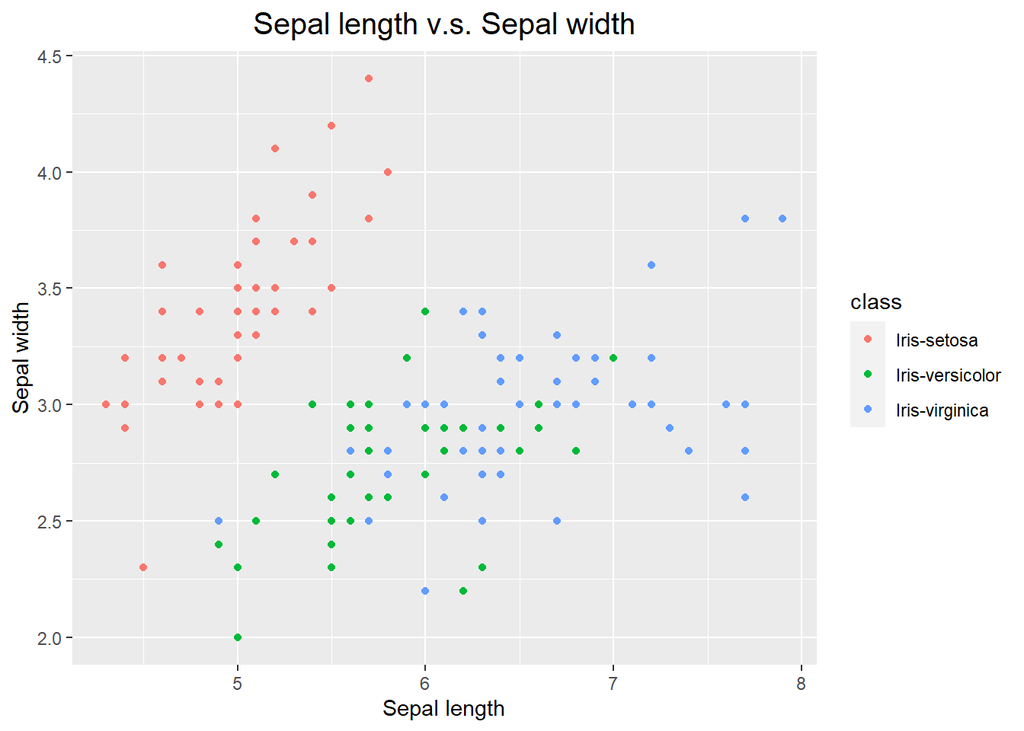

```r
df_1_p_1
```

2. Petal length v.s. petal width

```r
df_1_p_2 = ggplot(data = df_1,
                  mapping = aes(x = petal_length,
                                y = petal_width,
                                color = class)) +
  geom_point() +
  ggtitle("Petal length v.s. Petal width") +
  xlab("Petal length") +
  ylab("Petal width") +
  theme(plot.title = element_text(size = 15, hjust = 0.5))
```

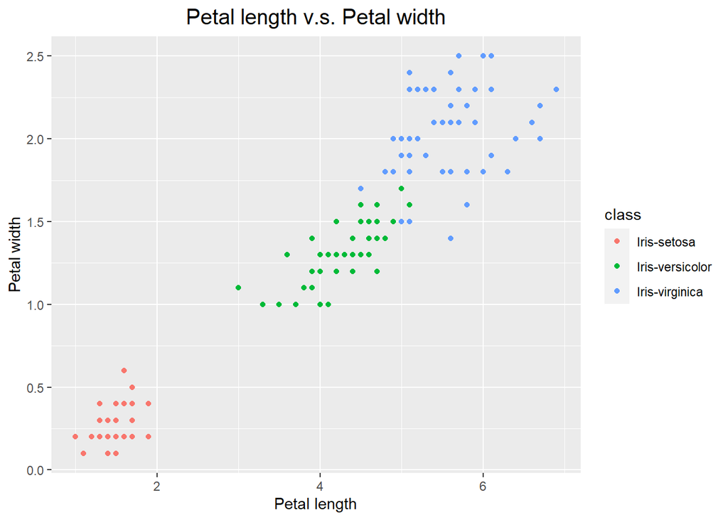

```r
df_1_p_2
```

## 3.2 Example 2: Wine

### 3.2.1 Descriptions

- `../public_dataset/wine.names`

```r
file_2 = site_url %>%
  paste0("public_dataset/wine.names") %>%
  read_file()
```

```r
file_2 %>% cat()
```

```
1. Title of Database: Wine recognition data
    Updated Sept 21, 1998 by C.Blake : Added attribute information

2. Sources:
   (a) Forina, M. et al, PARVUS - An Extendible Package for Data
       Exploration, Classification and Correlation. Institute of Pharmaceutical
       and Food Analysis and Technologies, Via Brigata Salerno,
       16147 Genoa, Italy.

   (b) Stefan Aeberhard, email: stefan@coral.cs.jcu.edu.au
   (c) July 1991
3. Past Usage:

   (1)
   S. Aeberhard, D. Coomans and O. de Vel,
   Comparison of Classifiers in High Dimensional Settings,
   Tech. Rep. no. 92-02, (1992), Dept. of Computer Science and Dept. of
   Mathematics and Statistics, James Cook University of North Queensland.
   (Also submitted to Technometrics).

   The data was used with many others for comparing various
   classifiers. The classes are separable, though only RDA
   has achieved 100% correct classification.
   (RDA : 100%, QDA 99.4%, LDA 98.9%, 1NN 96.1% (z-transformed data))
   (All results using the leave-one-out technique)

   In a classification context, this is a well posed problem
   with "well behaved" class structures. A good data set
   for first testing of a new classifier, but not very
   challenging.

   (2)
   S. Aeberhard, D. Coomans and O. de Vel,
   "THE CLASSIFICATION PERFORMANCE OF RDA"
   Tech. Rep. no. 92-01, (1992), Dept. of Computer Science and Dept. of
   Mathematics and Statistics, James Cook University of North Queensland.
   (Also submitted to Journal of Chemometrics).

   Here, the data was used to illustrate the superior performance of
   the use of a new appreciation function with RDA.
```

[output cut: 45 more lines]

```
    No statistics available, but suggest to standardise
    variables for certain uses (e.g. for us with classifiers
    which are NOT scale invariant)

    NOTE: 1st attribute is class identifier (1-3)

8. Missing Attribute Values:

    None

9. Class Distribution: number of instances per class

        class 1 59
    class 2 71
    class 3 48
```

### 3.2.2 Raw dataset

- `../public_dataset/wine.data`

```r
df_2 = site_url %>%
  paste0("public_dataset/wine.data") %>%
  read_csv(col_names = FALSE)

colnames(df_2) = c("class", "alcohol", "malic_acid", "ash", "alcalinity_of_ash", "magnesium", "total_phenols", "flavanoids", "nonflavanoid_phenols", "proanthocyanins", "color_intensity", "hue", "OD280_OD315_of_diluted_wines", "proline")
```

```r
df_2
```

| class | alcohol | malic_acid | ash | alcalinity_of_ash | magnesium | total_phenols | flavanoids | nonflavanoid_phenols | proanthocyanins | color_intensity | hue | OD280_OD315_of_diluted_wines | proline |
| --- | --- | --- | --- | --- | --- | --- | --- | --- | --- | --- | --- | --- | --- |
| 1 | 14.23 | 1.71 | 2.43 | 15.6 | 127 | 2.80 | 3.06 | 0.28 | 2.29 | 5.640000 | 1.040 | 3.92 | 1065 |
| 1 | 13.20 | 1.78 | 2.14 | 11.2 | 100 | 2.65 | 2.76 | 0.26 | 1.28 | 4.380000 | 1.050 | 3.40 | 1050 |
| 1 | 13.16 | 2.36 | 2.67 | 18.6 | 101 | 2.80 | 3.24 | 0.30 | 2.81 | 5.680000 | 1.030 | 3.17 | 1185 |
| 1 | 14.37 | 1.95 | 2.50 | 16.8 | 113 | 3.85 | 3.49 | 0.24 | 2.18 | 7.800000 | 0.860 | 3.45 | 1480 |
| 1 | 13.24 | 2.59 | 2.87 | 21.0 | 118 | 2.80 | 2.69 | 0.39 | 1.82 | 4.320000 | 1.040 | 2.93 | 735 |
| 1 | 14.20 | 1.76 | 2.45 | 15.2 | 112 | 3.27 | 3.39 | 0.34 | 1.97 | 6.750000 | 1.050 | 2.85 | 1450 |
| 1 | 14.39 | 1.87 | 2.45 | 14.6 | 96 | 2.50 | 2.52 | 0.30 | 1.98 | 5.250000 | 1.020 | 3.58 | 1290 |
| 1 | 14.06 | 2.15 | 2.61 | 17.6 | 121 | 2.60 | 2.51 | 0.31 | 1.25 | 5.050000 | 1.060 | 3.58 | 1295 |
| 1 | 14.83 | 1.64 | 2.17 | 14.0 | 97 | 2.80 | 2.98 | 0.29 | 1.98 | 5.200000 | 1.080 | 2.85 | 1045 |
| 1 | 13.86 | 1.35 | 2.27 | 16.0 | 98 | 2.98 | 3.15 | 0.22 | 1.85 | 7.220000 | 1.010 | 3.55 | 1045 |

[output cut: 168 more lines]

### 3.2.3 Clean dataset

- No need for cleaning

### 3.2.4 Inspect dataset

1. `class`
2. `alcohol`
3. `malic_acid`
4. `ash`
5. `alcalinity_of_ash`
6. `magnesium`
7. `total_phenols`
8. `flavanoids`
9. `nonflavanoid_phenols`
10. `proanthocyanins`
11. `color_intensity`
12. `hue`
13. `OD280_OD315_of_diluted_wines`
14. `proline`

```r
df_2 %>% summary()
```

```
     class          alcohol        malic_acid         ash
 Min.   :1.000   Min.   :11.03   Min.   :0.740   Min.   :1.360
 1st Qu.:1.000   1st Qu.:12.36   1st Qu.:1.603   1st Qu.:2.210
 Median :2.000   Median :13.05   Median :1.865   Median :2.360
 Mean   :1.938   Mean   :13.00   Mean   :2.336   Mean   :2.367
 3rd Qu.:3.000   3rd Qu.:13.68   3rd Qu.:3.083   3rd Qu.:2.558
 Max.   :3.000   Max.   :14.83   Max.   :5.800   Max.   :3.230
 alcalinity_of_ash   magnesium      total_phenols     flavanoids
 Min.   :10.60     Min.   : 70.00   Min.   :0.980   Min.   :0.340
 1st Qu.:17.20     1st Qu.: 88.00   1st Qu.:1.742   1st Qu.:1.205
 Median :19.50     Median : 98.00   Median :2.355   Median :2.135
 Mean   :19.49     Mean   : 99.74   Mean   :2.295   Mean   :2.029
 3rd Qu.:21.50     3rd Qu.:107.00   3rd Qu.:2.800   3rd Qu.:2.875
 Max.   :30.00     Max.   :162.00   Max.   :3.880   Max.   :5.080
 nonflavanoid_phenols proanthocyanins color_intensity       hue
 Min.   :0.1300       Min.   :0.410   Min.   : 1.280   Min.   :0.4800
 1st Qu.:0.2700       1st Qu.:1.250   1st Qu.: 3.220   1st Qu.:0.7825
 Median :0.3400       Median :1.555   Median : 4.690   Median :0.9650
 Mean   :0.3619       Mean   :1.591   Mean   : 5.058   Mean   :0.9574
 3rd Qu.:0.4375       3rd Qu.:1.950   3rd Qu.: 6.200   3rd Qu.:1.1200
 Max.   :0.6600       Max.   :3.580   Max.   :13.000   Max.   :1.7100
 OD280_OD315_of_diluted_wines    proline
 Min.   :1.270                Min.   : 278.0
 1st Qu.:1.938                1st Qu.: 500.5
 Median :2.780                Median : 673.5
 Mean   :2.612                Mean   : 746.9
 3rd Qu.:3.170                3rd Qu.: 985.0
 Max.   :4.000                Max.   :1680.0
```

### 3.2.5 Visualize dataset

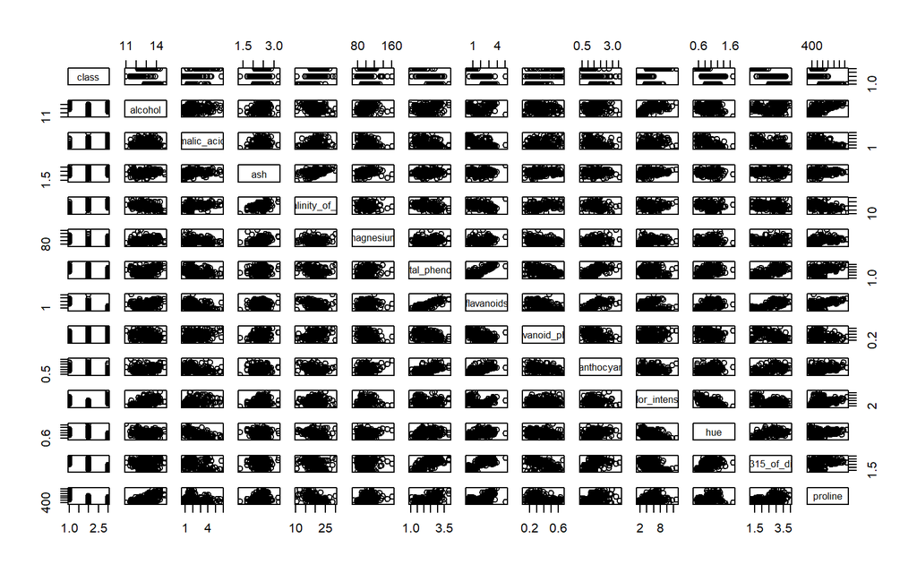

```r
plot(df_2)
```

# 4 Statistical Analysis / Modeling

[figure not shown]

## 4.1 Example 1: Iris

### 4.1.1 K-means

- From the “petal length v.s. petal width” plot, we can use the method “clustering”.
- Get training data

```r
df_1_petal = df_1 %>%
  select(petal_length, petal_width)
```

- Train a k-mean model

```r
df_1_petal_model_1 = df_1_petal %>%
  kmeans(centers = 3)
```

- View model

```r
df_1_petal_model_1 %>% class()
```

```
[1] "kmeans"
```

```r
df_1_petal_model_1
```

```
K-means clustering with 3 clusters of sizes 50, 54, 46

Cluster means:
  petal_length petal_width
1     1.464000    0.244000
2     4.292593    1.359259
3     5.626087    2.047826

Clustering vector:
  [1] 1 1 1 1 1 1 1 1 1 1 1 1 1 1 1 1 1 1 1 1 1 1 1 1 1 1 1 1 1 1 1 1 1 1 1 1 1
 [38] 1 1 1 1 1 1 1 1 1 1 1 1 1 2 2 2 2 2 2 2 2 2 2 2 2 2 2 2 2 2 2 2 2 2 2 2 2
 [75] 2 2 2 3 2 2 2 2 2 3 2 2 2 2 2 2 2 2 2 2 2 2 2 2 2 2 3 3 3 3 3 3 2 3 3 3 3
[112] 3 3 3 3 3 3 3 3 2 3 3 3 2 3 3 2 2 3 3 3 3 3 3 3 3 3 3 2 3 3 3 3 3 3 3 3 3
[149] 3 3

Within cluster sum of squares by cluster:
[1]  2.03840 14.22741 15.16348
 (between_SS / total_SS =  94.3 %)

Available components:

[1] "cluster"      "centers"      "totss"        "withinss"     "tot.withinss"
[6] "betweenss"    "size"         "iter"         "ifault"
```

```r
tidy(df_1_petal_model_1)
```

| petal_length | petal_width | size | withinss | cluster |
| --- | --- | --- | --- | --- |
| 1.464000 | 0.244000 | 50 | 2.03840 | 1 |
| 4.292593 | 1.359259 | 54 | 14.22741 | 2 |
| 5.626087 | 2.047826 | 46 | 15.16348 | 3 |

```r
summary(df_1_petal_model_1)
```

```
             Length Class  Mode
cluster      150    -none- numeric
centers        6    -none- numeric
totss          1    -none- numeric
withinss       3    -none- numeric
tot.withinss   1    -none- numeric
betweenss      1    -none- numeric
size           3    -none- numeric
iter           1    -none- numeric
ifault         1    -none- numeric
```

- Add predictions to the original dataset

```r
df_1_tidy = df_1_petal_model_1 %>%
  tidy() %>%
  select(cluster, petal_length_predicted_center = petal_length, petal_width_predicted_center = petal_width)

df_1_petal_prediction_1 = df_1_petal_model_1 %>%
  augment(df_1) %>%
  rename(cluster = .cluster) %>%
  left_join(df_1_tidy, by = c("cluster"))
```

```r
df_1_petal_prediction_1
```

| sepal_length | sepal_width | petal_length | petal_width | class | cluster | petal_length_predicted_center | petal_width_predicted_center |
| --- | --- | --- | --- | --- | --- | --- | --- |
| 5.1 | 3.5 | 1.4 | 0.2 | Iris-setosa | 1 | 1.464000 | 0.244000 |
| 4.9 | 3.0 | 1.4 | 0.2 | Iris-setosa | 1 | 1.464000 | 0.244000 |
| 4.7 | 3.2 | 1.3 | 0.2 | Iris-setosa | 1 | 1.464000 | 0.244000 |
| 4.6 | 3.1 | 1.5 | 0.2 | Iris-setosa | 1 | 1.464000 | 0.244000 |
| 5.0 | 3.6 | 1.4 | 0.2 | Iris-setosa | 1 | 1.464000 | 0.244000 |
| 5.4 | 3.9 | 1.7 | 0.4 | Iris-setosa | 1 | 1.464000 | 0.244000 |
| 4.6 | 3.4 | 1.4 | 0.3 | Iris-setosa | 1 | 1.464000 | 0.244000 |
| 5.0 | 3.4 | 1.5 | 0.2 | Iris-setosa | 1 | 1.464000 | 0.244000 |
| 4.4 | 2.9 | 1.4 | 0.2 | Iris-setosa | 1 | 1.464000 | 0.244000 |
| 4.9 | 3.1 | 1.5 | 0.1 | Iris-setosa | 1 | 1.464000 | 0.244000 |

[output cut: 140 more lines]

- Visualize predictions

```r
df_1_p_2 = ggplot(data = df_1_petal_prediction_1) +
  geom_point(mapping = aes(x = petal_length,
                           y = petal_width,
                           color = cluster)) +
  geom_point(mapping = aes(x = petal_length_predicted_center,
                           y = petal_width_predicted_center),
             size = 10,
             shape = "x") +
  ggtitle("Sepal length v.s. Sepal width Clustering") +
  xlab("Sepal length") +
  ylab("Sepal width") +
  theme(plot.title = element_text(size = 15, hjust = 0.5))
```

[figure not shown]

```r
df_1_p_2
```

**Copyright © 2022 Harry Lu. All rights reserved.**